# Atividade Analise multivariada II

Amauri dos Santos Lima Neto, José Wellington Cavalcanti

# Análise discriminante

## Método utilizado

A análise discriminante é uma técnica estatística utilizada para classificar observações em grupos predefinidos com base em várias variáveis preditoras. O objetivo é desenvolver uma ou mais funções discriminantes que melhor diferenciam os grupos com base nas variáveis disponíveis. A técnica é comumente aplicada em estatísticas, aprendizado de máquina e outras áreas que requerem classificação de dados em categorias distintas.

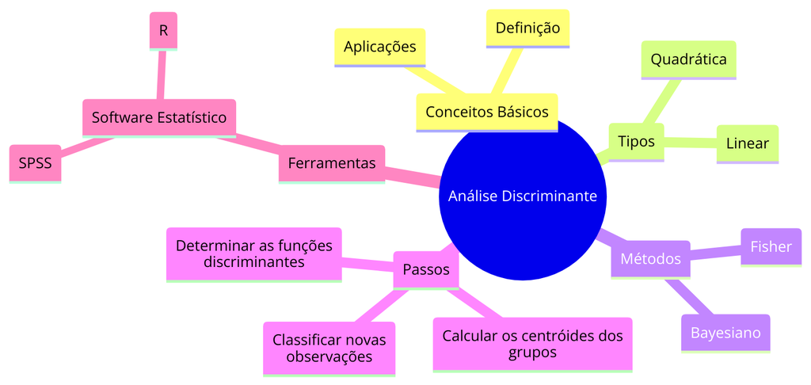

diagrama de uma análise discriminante

### Aplicações comuns

**Classificação de Clientes:** Determinar a qual segmento de clientes um novo cliente pertence com base em características conhecidas.

**Diagnóstico Médico:** Classificar pacientes em categorias de doenças com base em resultados de exames.

**Reconhecimento de Padrões:** Usado em aprendizado de máquina para tarefas como reconhecimento facial, reconhecimento de voz, e classificação de texto.

### Metodologia

A análise discriminante envolve a construção de um modelo que calcula a probabilidade de uma observação pertencer a cada grupo. A classificação é frequentemente realizada calculando-se uma pontuação baseada nas funções discriminantes e classificando a observação no grupo para o qual a pontuação é mais alta.

$$y= w_1x_1+w_2x_2+w_3x_3+...+w_nx_n$$

onde $w_1,w_2,...,w_n$ são os coeficientes da função discriminante e determinados de modo que maximiza a distância entre as médias de cada grupo enquanto minimiza a variância dentro dos grupos

### nome do banco de dados: Previsão de doenças cardíacas

## Sobre os dados

**Age:** Idade do paciente.

**Sex:** O sexo do paciente.

**Chest pain type:** Um atributo categórico que indica o tipo de dor torácica experimentada pelo paciente. Tem quatro valores possíveis.

**Resting blood pressure:** A pressão arterial em repouso do paciente.

**Serum cholesterol:** O nível de colesterol sérico em mg/dl do paciente.

**Fasting blood sugar:** Indica se o açúcar no sangue em jejum do paciente é maior que 120 mg/dl.

**Resting electrocardiographic results:** Um atributo categórico que representa os resultados do eletrocardiograma de repouso. Tem três valores possíveis.

**Maximum heart rate achieved:** A frequência cardíaca máxima alcançada pelo paciente.

**Exercise induced angina:** Indica se o paciente experimentou angina (dor no peito) induzida pelo exercício.

**Oldpeak:** Depressão ST induzida pelo exercício em relação ao repouso.

**Slope:** A inclinação do segmento ST de pico de exercício.

**Target:** A coluna alvo serve como variável de desfecho e indica a presença de doença cardíaca no paciente. Um valor de 0 significa a ausência de doença cardíaca, enquanto um valor de 1 indica a presença de doença cardíaca.

## Análise descritiva.

```r
descr(dados2)
```

```
## Non-numerical variable(s) ignored: sex, cp, fbs, restecg, exang, slope, ca, thal, target
```

```
## Descriptive Statistics
## dados2
## N: 1025
##
##                         age      chol   oldpeak   thalach   trestbps
## ----------------- --------- --------- --------- --------- ----------
##              Mean     54.43    246.00      1.07    149.11     131.61
##           Std.Dev      9.07     51.59      1.18     23.01      17.52
##               Min     29.00    126.00      0.00     71.00      94.00
##                Q1     48.00    211.00      0.00    132.00     120.00
##            Median     56.00    240.00      0.80    152.00     130.00
##                Q3     61.00    275.00      1.80    166.00     140.00
##               Max     77.00    564.00      6.20    202.00     200.00
##               MAD      8.90     48.93      1.19     23.72      14.83
##               IQR     13.00     64.00      1.80     34.00      20.00
##                CV      0.17      0.21      1.10      0.15       0.13
##          Skewness     -0.25      1.07      1.21     -0.51       0.74
##       SE.Skewness      0.08      0.08      0.08      0.08       0.08
##          Kurtosis     -0.53      3.96      1.29     -0.10       0.97
##           N.Valid   1025.00   1025.00   1025.00   1025.00    1025.00
##         Pct.Valid    100.00    100.00    100.00    100.00     100.00
```

```r
freq(dados2)
```

```
## Variable(s) ignored: age, trestbps, chol, thalach, oldpeak
```

```
## Frequencies
## dados2$sex
## Type: Factor
##
##               Freq   % Valid   % Valid Cum.   % Total   % Total Cum.
## ----------- ------ --------- -------------- --------- --------------
##           0    312     30.44          30.44     30.44          30.44
##           1    713     69.56         100.00     69.56         100.00
##        <NA>      0                               0.00         100.00
##       Total   1025    100.00         100.00    100.00         100.00
##
## dados2$cp
## Type: Factor
##
##               Freq   % Valid   % Valid Cum.   % Total   % Total Cum.
## ----------- ------ --------- -------------- --------- --------------
##           0    497     48.49          48.49     48.49          48.49
##           1    167     16.29          64.78     16.29          64.78
##           2    284     27.71          92.49     27.71          92.49
##           3     77      7.51         100.00      7.51         100.00
##        <NA>      0                               0.00         100.00
##       Total   1025    100.00         100.00    100.00         100.00
##
## dados2$fbs
## Type: Factor
##
##               Freq   % Valid   % Valid Cum.   % Total   % Total Cum.
## ----------- ------ --------- -------------- --------- --------------
##           0    872     85.07          85.07     85.07          85.07
##           1    153     14.93         100.00     14.93         100.00
##        <NA>      0                               0.00         100.00
##       Total   1025    100.00         100.00    100.00         100.00
##
## dados2$restecg
## Type: Factor
##
##               Freq   % Valid   % Valid Cum.   % Total   % Total Cum.
## ----------- ------ --------- -------------- --------- --------------
##           0    497     48.49          48.49     48.49          48.49
##           1    513     50.05          98.54     50.05          98.54
```

[output cut: 44 more lines]

```
##           1     64      6.24           6.93      6.24           6.93
##           2    544     53.07          60.00     53.07          60.00
##           3    410     40.00         100.00     40.00         100.00
##        <NA>      0                               0.00         100.00
##       Total   1025    100.00         100.00    100.00         100.00
##
## dados2$target
## Type: Factor
##
##               Freq   % Valid   % Valid Cum.   % Total   % Total Cum.
## ----------- ------ --------- -------------- --------- --------------
##           0    499     48.68          48.68     48.68          48.68
##           1    526     51.32         100.00     51.32         100.00
##        <NA>      0                               0.00         100.00
##       Total   1025    100.00         100.00    100.00         100.00
```

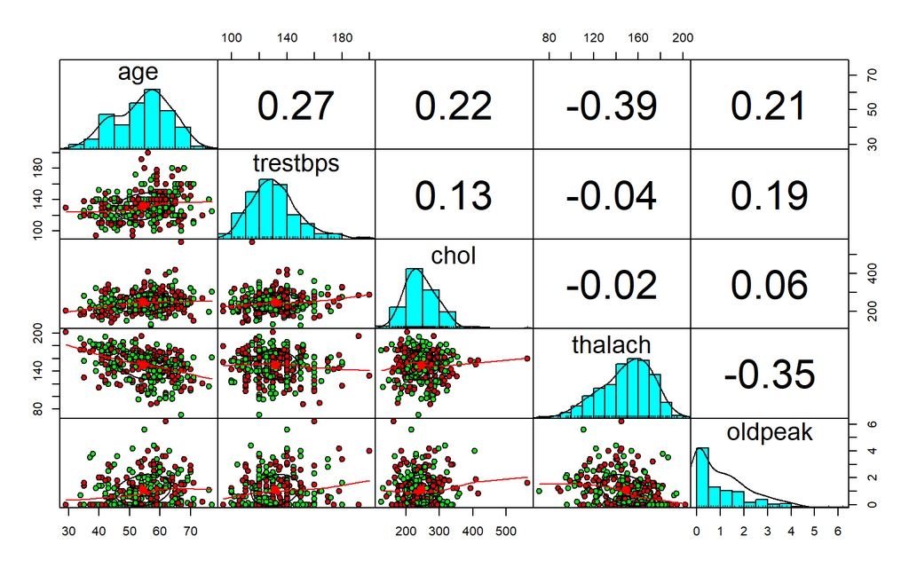

```r
pairs.panels(dados2[,c(1,4,5,8,10)],
             gap = 0,
             bg = c("red","green"),
             pch = 21)
```

## Criação do modelo:

```r
library(MASS)
linear<- lda(target ~.,dados2)
linear
```

```
## Call:
## lda(target ~ ., data = dados2)
##
## Prior probabilities of groups:
##         0         1
## 0.4868293 0.5131707
##
## Group means:
##        age      sex1        cp1       cp2        cp3 trestbps     chol
## 0 56.56914 0.8276553 0.06613226 0.1302605 0.05210421 134.1062 251.2926
## 1 52.40875 0.5703422 0.25475285 0.4163498 0.09695817 129.2452 240.9791
##        fbs1  restecg1    restecg2  thalach    exang1  oldpeak    slope1
## 0 0.1643287 0.4088176 0.024048096 139.1303 0.5490982 1.600200 0.6492986
## 1 0.1349810 0.5874525 0.005703422 158.5856 0.1349810 0.569962 0.3003802
##      slope2       ca1        ca2        ca3         ca4      thal1     thal2
## 0 0.2585170 0.3206413 0.22645291 0.12024048 0.006012024 0.08617234 0.2645291
## 1 0.6463878 0.1254753 0.03992395 0.01711027 0.028517110 0.03992395 0.7832700
##       thal3
## 0 0.6412826
## 1 0.1711027
##
## Coefficients of linear discriminants:
##                   LD1
## age       0.009978493
## sex1     -0.727076617
## cp1       0.717184279
## cp2       0.926711741
## cp3       1.027702322
## trestbps -0.008703752
## chol     -0.001671805
## fbs1      0.107169462
## restecg1  0.163850649
## restecg2 -0.389112937
## thalach   0.007592253
## exang1   -0.354299672
## oldpeak  -0.167162225
## slope1   -0.193538330
## slope2    0.345901241
## ca1      -1.106392923
## ca2      -1.403059202
## ca3      -1.196034799
## ca4       0.310956249
## thal1     1.063095130
## thal2     1.257949871
## thal3     0.432960645
```

```r
p<-predict(linear, dados2)
```

## Comparação entre os grupos preditos

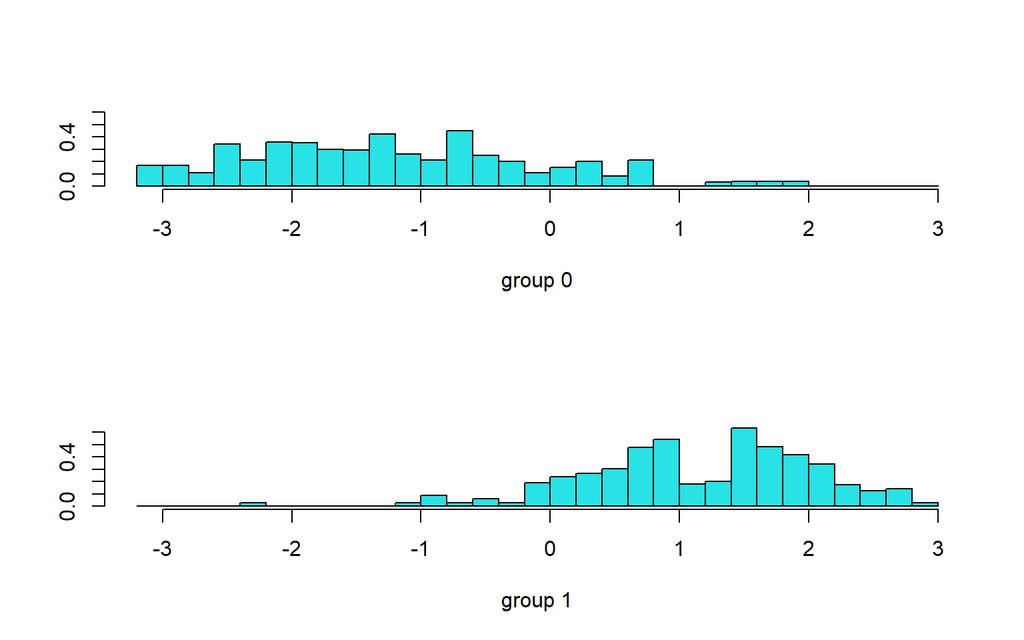

```r
ldahist(data = p$x[,1], g=dados2$target)
```

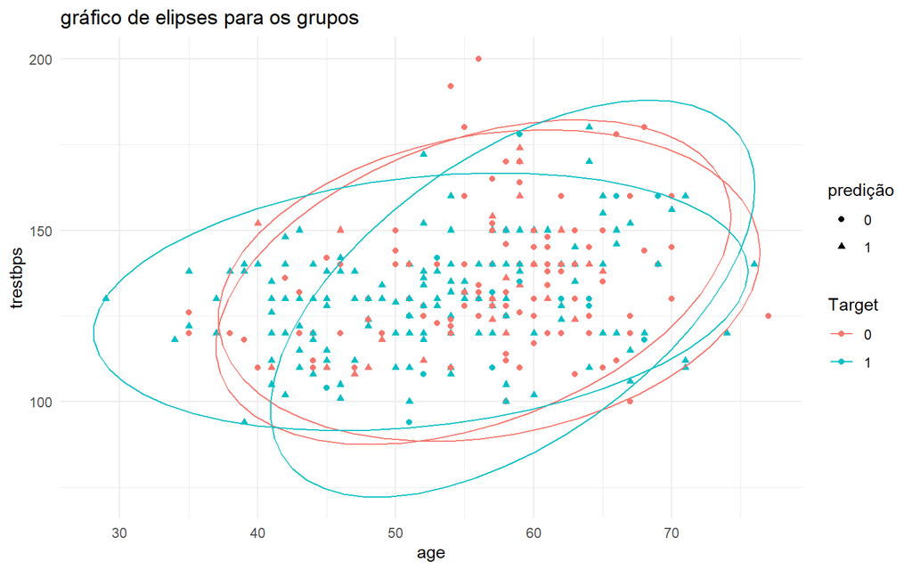

```r
dados2$predicao <- predict(linear)$class


ggplot(dados2, aes(x =age, y = trestbps, color = as.factor(target), shape = predicao)) +
  geom_point() +
  stat_ellipse(type = "norm", level = 0.95) +  # Adiciona as elipses de dispersão
  labs(color = "Target", shape = "predição", title="gráfico de elipses para os grupos") +  # Personaliza as legendas
  theme_minimal()  # Define um tema para o gráfico
```

## tabelas de confusão para o modelo aplicado nos dados de teste e treino

### Treino

```r
p1<- predict(linear, dados2)$class
tab<-table(Predicted = p1, Actual = dados2$target)
tab
```

```
##          Actual
## Predicted   0   1
##         0 412  47
##         1  87 479
```

### acurácia

```r
sum(diag(tab))/sum(tab)
```

```
## [1] 0.8692683
```

### Teste

```r
p2<- predict(linear, testing)$class
tab1<- table(Predicted = p2 , Actual = testing$target)
tab1
```

```
##          Actual
## Predicted   0   1
##         0 114  15
##         1  24 150
```

### acurácia

```r
sum(diag(tab1))/sum(tab1)
```

```
## [1] 0.8712871
```

Ou seja, para os dados de teste o modelo apresentou uma acurácia de aproximadamente 87%

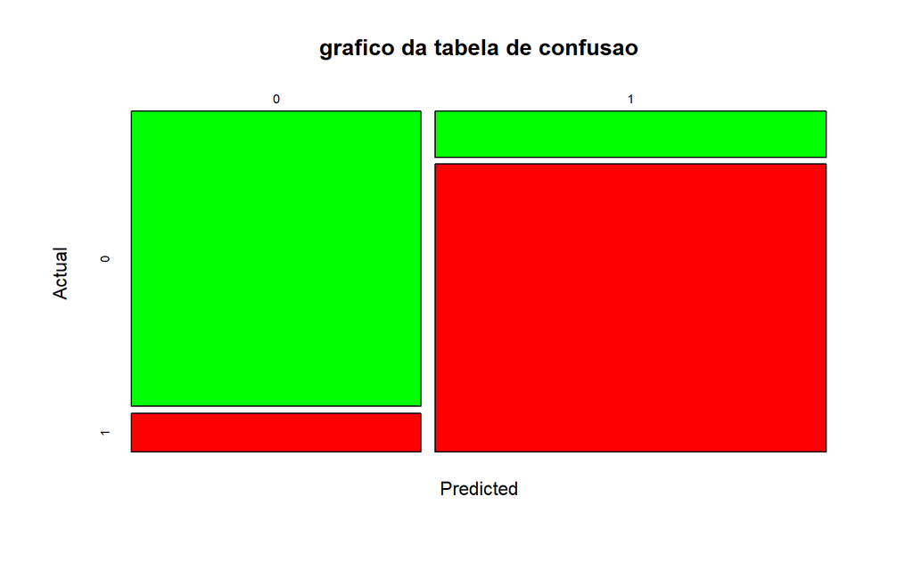

```r
plot(tab1, col= c('green','red'), main = "grafico da tabela de confusao")
```